# Data Review

## Load The Data

```r
df <- read_excel("~/file.xlsx")
head(df)
```

```
## # A tibble: 6 × 41
##   age_upon_outcome animal_id_outcome date_of_birth       outcome_subtype
##   <chr>            <chr>             <dttm>              <chr>
## 1 10 years         A006100           2007-07-09 00:00:00 <NA>
## 2 7 years          A006100           2007-07-09 00:00:00 <NA>
## 3 6 years          A006100           2007-07-09 00:00:00 <NA>
## 4 10 years         A047759           2004-04-02 00:00:00 Partner
## 5 16 years         A134067           1997-10-16 00:00:00 <NA>
## 6 15 years         A141142           1998-06-01 00:00:00 <NA>
## # ℹ 37 more variables: outcome_type <chr>, sex_upon_outcome <chr>,
## #   `age_upon_outcome_(days)` <dbl>, `age_upon_outcome_(years)` <dbl>,
## #   age_upon_outcome_age_group <chr>, outcome_datetime <dttm>,
## #   outcome_month <dbl>, outcome_year <dbl>, outcome_monthyear <chr>,
## #   outcome_weekday <chr>, outcome_hour <dbl>, outcome_number <dbl>,
## #   dob_year <dbl>, dob_month <dbl>, dob_monthyear <chr>,
## #   age_upon_intake <chr>, animal_id_intake <chr>, animal_type <chr>, …
```

Raw data includes 41 columns.

## Clean The Data

Imbalanced Data:

```r
table(df$animal_type)
```

```
##
##  Bird   Cat   Dog Other
##   339 29539 45366  4428
```

```r
df %>%
  count(animal_type, sort = TRUE)
```

```
## # A tibble: 4 × 2
##   animal_type     n
##   <chr>       <int>
## 1 Dog         45366
## 2 Cat         29539
## 3 Other        4428
## 4 Bird          339
```

Since Most Data Divides Between Dogs And Cats We Will Focuse On Those Types.

Keep Dogs And Cats Only,Drop unnaccary columns:

```r
df <- df %>%
  filter(animal_type %in% c("Dog", "Cat")) %>%
  select(-age_upon_outcome,-time_in_shelter,-animal_id_outcome,-date_of_birth,-sex_upon_outcome,-`age_upon_outcome_(days)`,-`age_upon_outcome_(years)`,-age_upon_outcome_age_group,-outcome_datetime,-outcome_month,-outcome_year,-outcome_monthyear,-outcome_weekday,-outcome_hour,-outcome_number,-dob_year,-dob_month,-dob_monthyear,-animal_id_intake,-found_location,-intake_type,-count,-age_upon_intake,-`age_upon_intake_(days)`,-age_upon_intake_age_group,-intake_datetime,-intake_month,-intake_year,-intake_monthyear,-intake_weekday,-intake_hour,-intake_number,-time_in_shelter_days,-outcome_subtype)

dim(df)
```

```
## [1] 74905     7
```

Null values:

```r
colSums(is.na(df))
```

```
##            outcome_type             animal_type                   breed
##                       5                       0                       0
##                   color        intake_condition         sex_upon_intake
##                       0                       0                       1
## age_upon_intake_(years)
##                       0
```

Few null values-dropping rows:

```r
df <- na.omit(df)
colSums(is.na(df))
```

```
##            outcome_type             animal_type                   breed
##                       0                       0                       0
##                   color        intake_condition         sex_upon_intake
##                       0                       0                       0
## age_upon_intake_(years)
##                       0
```

## Adjust columns, Feature engineering

```r
table(df$outcome_type)
```

```
##
##        Adoption            Died        Disposal      Euthanasia         Missing
##           33256             544              23            2977              45
## Return to Owner       Rto-Adopt        Transfer
##           14743             179           23132
```

Merging outcome categories to Adopted/Not Adopted:

```r
outcome_mapping <- c(
    'Adoption'= "Adopted",
    'Rto-Adopt'="Adopted" ,
    'Died'= "Not_Adopted",
    'Disposal'= "Not_Adopted",
    'Euthanasia'= "Not_Adopted",
    'Missing'= "Not_Adopted",
    'Return to Owner'= "DELETE",
    'Transfer'= "DELETE"
)
df$outcome_type <- outcome_mapping[df$outcome_type]
df <- df[df$outcome_type!="DELETE",]
table(df$outcome_type)
```

```
##
##     Adopted Not_Adopted
##       33435        3589
```

Although the resulting classes are still imbalanced, we will handle the imbalance later during model training using smote.

Turn breed into Mixed/Purebred:

```r
df$"mixed_purebred" <- ifelse(grepl("Mix", df$breed) | grepl("/", df$breed), "Mixed" , "Purebred")
df <- df %>%
  select(-breed)
table(df$"mixed_purebred")
```

```
##
##    Mixed Purebred
##    35508     1516
```

Merging different colors into 3 categories:

```r
df <- df %>%
  mutate(color_group = case_when(
    grepl("Black", color, ignore.case = TRUE) ~ "Black",
    grepl("Brown|Tan|Buff|Red|Gold|Sable|Brindle|Merle|Smoke|Chocolate|Fawn|Liver|Agouti|Chocolate Point|Tabby|Tick|Tortie|Torbie|Chocolate
", color, ignore.case = TRUE) ~ "Brown",
    grepl("White|Cream|Light|Yellow|Gray|Orange|Silver|Apricot|Pink|Blue|Lynx Point|Seal Point|Point|Silver Tabby|Silver|Calico|Calico Point|Tortie Point|Tricolor|Torbie
", color, ignore.case = TRUE) ~ "Light",
    TRUE ~ "Unknown"
  ))
df <- df %>%
  select(-color)
table(df$color_group)
```

```
##
## Black Brown Light
## 11712 18667  6645
```

Turn health_status into Healthy/Sick-Aged-Pregnant:

```r
df <- df %>%
  mutate(health_status = case_when(
    intake_condition == "Normal" ~ "Healthy",
    TRUE ~ "Sick_Aged_Pregnant"
  )) %>%
  select(-intake_condition)

table(df$health_status)
```

```
##
##            Healthy Sick_Aged_Pregnant
##              33161               3863
```

Turn sex_upon_intake into sex and neutered columns:

```r
df <- df %>%
  mutate(
    sex = case_when(
      str_detect(sex_upon_intake, "Male") ~ "Male",
      str_detect(sex_upon_intake, "Female") ~ "Female",
      TRUE ~ "Unknown"
    ),
    neutered = ifelse(str_detect(sex_upon_intake, "Neutered|Spayed"), "Neutered_Spayed","Intact")
  ) %>%
  select(-sex_upon_intake)

table(df$sex)
```

```
##
##  Female    Male Unknown
##   18056   18626     342
```

```r
table(df$neutered)
```

```
##
##          Intact Neutered_Spayed
##           26953           10071
```

```r
df <- df %>%
  mutate(
    animal_type = case_when(
      str_detect(animal_type, "Dog") ~ "Dog",
      str_detect(animal_type, "Cat") ~ "Cat",
      TRUE ~ "Unknown"
    ))
table(df$animal_type)
```

```
##
##   Cat   Dog
## 14630 22394
```

Change “age_upon_intake_(years)” into age_groups, and age_norm:

```r
df["age_norm"]=df$`age_upon_intake_(years)`/max(df$`age_upon_intake_(years)`)
df <- df %>%
  mutate(age_group = case_when(
  `age_upon_intake_(years)`  <= 0.5 ~ "Puppy_Kitten",
  `age_upon_intake_(years)`  <= 2 ~"Juvenile",
  `age_upon_intake_(years)`  <= 7 ~"Adult",
  `age_upon_intake_(years)`  > 7 ~ "Senior",
    TRUE ~ "Unknown"
  )) %>%
  select (-`age_upon_intake_(years)`)
df<-df[df$sex!="Unknown",]
table(df$age_group)
```

```
##
##        Adult     Juvenile Puppy_Kitten       Senior
##         5643        13145        15729         2165
```

convert categorical columns to factors:

```r
df$outcome_type<-as.factor(df$outcome_type)
df$mixed_purebred<-as.factor(df$mixed_purebred)
df$color_group<-as.factor(df$color_group)
df$animal_type<-as.factor(df$animal_type)
df$health_status<-as.factor(df$health_status)
df$sex<-as.factor(df$sex)
df$neutered<-as.factor(df$neutered)
df$age_group<-as.factor(df$age_group)
```

View the data after changes:

```r
str(df)
```

```
## tibble [36,682 × 9] (S3: tbl_df/tbl/data.frame)
##  $ outcome_type  : Factor w/ 2 levels "Adopted","Not_Adopted": 1 2 1 2 2 2 2 1 2 1 ...
##   ..- attr(*, "names")= chr [1:36682] "Adoption" "Euthanasia" "Adoption" "Euthanasia" ...
##  $ animal_type   : Factor w/ 2 levels "Cat","Dog": 2 2 2 1 2 2 2 2 2 2 ...
##  $ mixed_purebred: Factor w/ 2 levels "Mixed","Purebred": 1 1 2 2 2 2 1 1 2 1 ...
##  $ color_group   : Factor w/ 3 levels "Black","Brown",..: 1 1 1 1 2 2 2 2 2 1 ...
##  $ health_status : Factor w/ 2 levels "Healthy","Sick_Aged_Pregnant": 1 2 2 2 2 2 2 1 2 1 ...
##  $ sex           : Factor w/ 2 levels "Female","Male": 2 2 2 1 2 2 1 2 2 1 ...
##  $ neutered      : Factor w/ 2 levels "Intact","Neutered_Spayed": 2 2 2 2 2 2 2 2 1 2 ...
##  $ age_norm      : num [1:36682] 0.727 0.636 0.773 0.864 0.682 ...
##  $ age_group     : Factor w/ 4 levels "Adult","Juvenile",..: 4 4 4 4 4 4 4 4 4 4 ...
##  - attr(*, "na.action")= 'omit' Named int [1:6] 6405 41824 55745 67133 67137 67139
##   ..- attr(*, "names")= chr [1:6] "6405" "41824" "55745" "67133" ...
```

```r
colSums(is.na(df))
```

```
##   outcome_type    animal_type mixed_purebred    color_group  health_status
##              0              0              0              0              0
##            sex       neutered       age_norm      age_group
##              0              0              0              0
```

Data is cleaned and adjusted

```r
write.csv(
  df,
  file = "clean_data.csv",
  row.names = FALSE,
  fileEncoding = "UTF-8"
)
```

## Review the cleaned data

```r
summary(df)
```

```
##       outcome_type   animal_type  mixed_purebred  color_group
##  Adopted    :33434   Cat:14328   Mixed   :35176   Black:11593
##  Not_Adopted: 3248   Dog:22354   Purebred: 1506   Brown:18506
##                                                   Light: 6583
##
##
##
##             health_status       sex                   neutered
##  Healthy           :33056   Female:18056   Intact         :26611
##  Sick_Aged_Pregnant: 3626   Male  :18626   Neutered_Spayed:10071
##
##
##
##
##     age_norm               age_group
##  Min.   :0.000000   Adult       : 5643
##  1st Qu.:0.007472   Juvenile    :13145
##  Median :0.045455   Puppy_Kitten:15729
##  Mean   :0.082538   Senior      : 2165
##  3rd Qu.:0.090909
##  Max.   :1.000000
```

Most of the data is inherently imbalanced due to the typical characteristics of animals that end up in shelters. We address the class imbalance within the outcome_type target variable by incorporating SMOTE directly into our cross-validation training process. For these imbalances within the explanatory features, we leverage the inherent robustness of the XGBoost algorithm. Tree-based ensemble methods like XGBoost are generally less sensitive to skewed or imbalanced distributions in predictor variables compared to some other machine learning algorithms.

Review the data:

```r
str(df)
```

```
## tibble [36,682 × 9] (S3: tbl_df/tbl/data.frame)
##  $ outcome_type  : Factor w/ 2 levels "Adopted","Not_Adopted": 1 2 1 2 2 2 2 1 2 1 ...
##   ..- attr(*, "names")= chr [1:36682] "Adoption" "Euthanasia" "Adoption" "Euthanasia" ...
##  $ animal_type   : Factor w/ 2 levels "Cat","Dog": 2 2 2 1 2 2 2 2 2 2 ...
##  $ mixed_purebred: Factor w/ 2 levels "Mixed","Purebred": 1 1 2 2 2 2 1 1 2 1 ...
##  $ color_group   : Factor w/ 3 levels "Black","Brown",..: 1 1 1 1 2 2 2 2 2 1 ...
##  $ health_status : Factor w/ 2 levels "Healthy","Sick_Aged_Pregnant": 1 2 2 2 2 2 2 1 2 1 ...
##  $ sex           : Factor w/ 2 levels "Female","Male": 2 2 2 1 2 2 1 2 2 1 ...
##  $ neutered      : Factor w/ 2 levels "Intact","Neutered_Spayed": 2 2 2 2 2 2 2 2 1 2 ...
##  $ age_norm      : num [1:36682] 0.727 0.636 0.773 0.864 0.682 ...
##  $ age_group     : Factor w/ 4 levels "Adult","Juvenile",..: 4 4 4 4 4 4 4 4 4 4 ...
##  - attr(*, "na.action")= 'omit' Named int [1:6] 6405 41824 55745 67133 67137 67139
##   ..- attr(*, "names")= chr [1:6] "6405" "41824" "55745" "67133" ...
```

The dataset includes 9 features, which can be grouped as follows:

Outcome Information: outcome_type

Animal Characteristics: animal_type, mixed_purebred, color_group, sex, neutered, age_group, age_norm,

Health Status: health_status

Null values check:

```r
colSums(is.na(df))
```

```
##   outcome_type    animal_type mixed_purebred    color_group  health_status
##              0              0              0              0              0
##            sex       neutered       age_norm      age_group
##              0              0              0              0
```

No null values after cleaning the data.

## Visualization

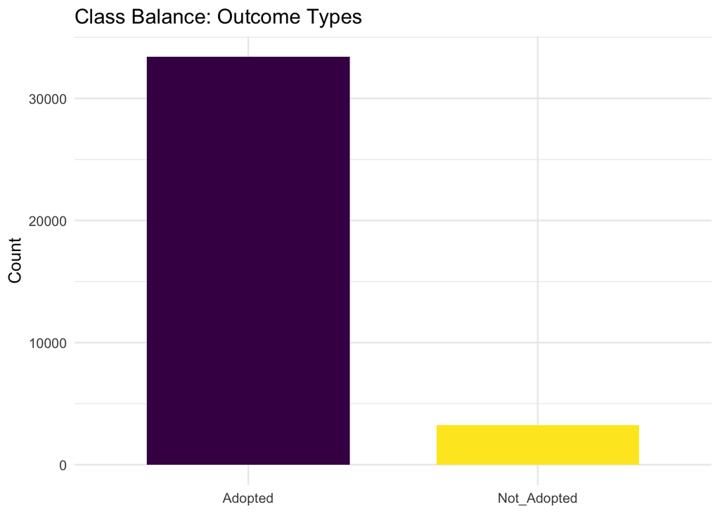

```r
ggplot(df, aes(x = outcome_type, fill = outcome_type)) +
  geom_bar(width = 0.7, show.legend = FALSE) +
  scale_fill_viridis_d() +
  labs(title = "Class Balance: Outcome Types",
       x = NULL, y = "Count") +
  theme_minimal(base_size = 12)
```

# Observation :

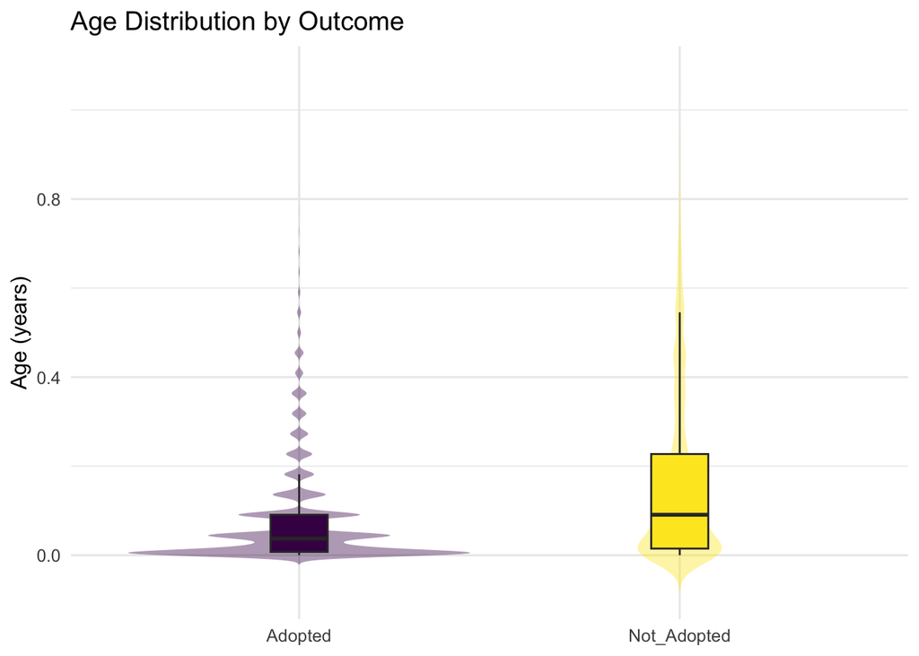

```r
ggplot(df, aes(x = outcome_type, y = age_norm, fill = outcome_type)) +
  geom_violin(trim = FALSE, alpha = 0.4, colour = NA) +
  geom_boxplot(width = 0.15, outlier.shape = NA, colour = "grey20") +
  scale_fill_viridis_d() +
  labs(title = "Age Distribution by Outcome",
       x = NULL, y = "Age (years)") +
  theme_minimal(base_size = 12) +
  theme(legend.position = "none")
```

# Observation :

Adopted animals are markedly younger on average than those not adopted, hinting that age will be a key predictor.

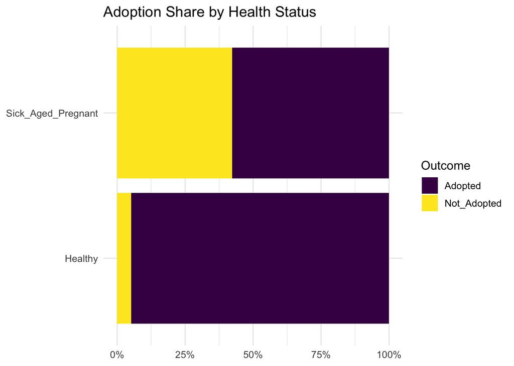

```r
df %>%
  mutate(health_status = fct_lump_n(health_status, 6)) %>%  # keep top 6 statuses
  group_by(health_status, outcome_type) %>%
  summarise(n = n(), .groups = "drop") %>%
  group_by(health_status) %>%
  mutate(prop = n / sum(n)) %>%
  ggplot(aes(health_status, prop, fill = outcome_type)) +
  geom_col(position = "fill") +
  scale_y_continuous(labels = percent_format()) +
  scale_fill_viridis_d(name = "Outcome") +
  coord_flip() +
  labs(title = "Adoption Share by Health Status",
       x = NULL, y = NULL) +
  theme_minimal(base_size = 12)
```

# Observation :

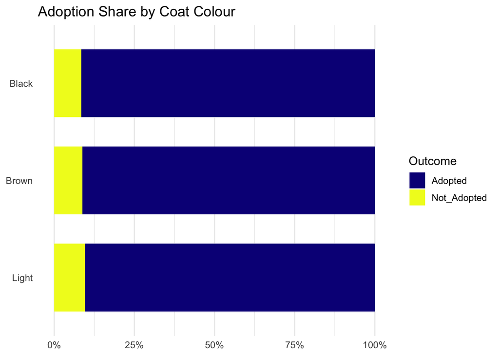

```r
plot_colour_rates <- df %>%
  mutate(color_group = fct_lump_n(color_group, 8)) %>%          # top-8 colours
  count(color_group, outcome_type, name = "n") %>%
  group_by(color_group) %>%
  mutate(prop = n / sum(n)) %>%                                 # share within colour
  ungroup() %>%
  ggplot(aes(y = fct_rev(color_group), x = prop, fill = outcome_type)) +
  geom_col(position = "fill", width = 0.7) +
  scale_x_continuous(labels = percent_format(accuracy = 1)) +
  scale_fill_viridis_d(option = "C", name = "Outcome") +
  labs(
    title = "Adoption Share by Coat Colour",
    x = NULL, y = NULL
  ) +
  theme_minimal(base_size = 12) +
  theme(
    panel.grid.major.y = element_blank(),
    axis.ticks.y       = element_blank()
  )

plot_colour_rates
```

# Observation :

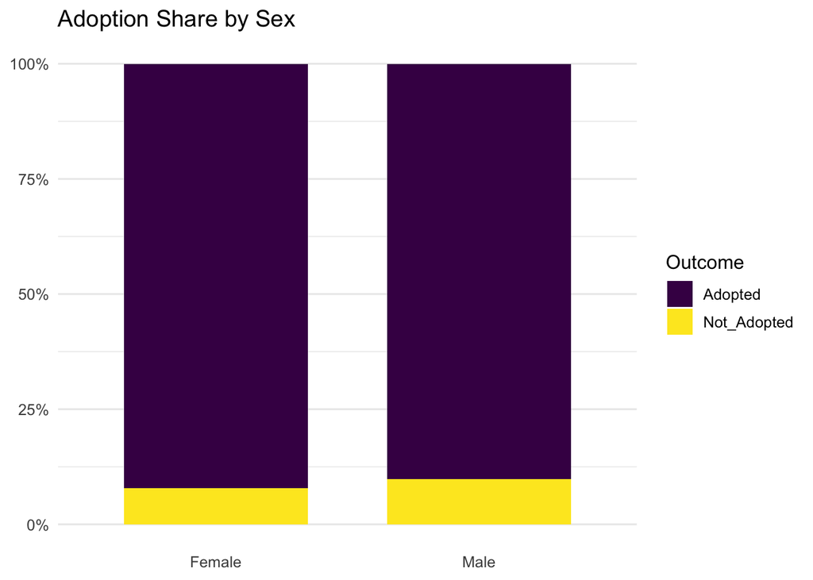

```r
plot_sex_rates <- df %>%
  mutate(sex_simple = case_when(
    str_detect(sex, "Male")   ~ "Male",
    str_detect(sex, "Female") ~ "Female",
    TRUE                                   ~ "Unknown"
  )) %>%
  count(sex_simple, outcome_type, name = "n") %>%
  group_by(sex_simple) %>%
  mutate(prop = n / sum(n)) %>%
  ungroup() %>%
  ggplot(aes(x = sex_simple, y = prop, fill = outcome_type)) +
  geom_col(position = "fill", width = 0.7) +
  scale_y_continuous(labels = percent_format(accuracy = 1)) +
  scale_fill_viridis_d(option = "D", name = "Outcome") +
  labs(
    title = "Adoption Share by Sex",
    x     = NULL, y = NULL
  ) +
  theme_minimal(base_size = 12) +
  theme(
    panel.grid.major.x = element_blank(),
    axis.ticks.x       = element_blank()
  )

plot_sex_rates
```

# Observation :

## Methods & Results

Parallel-processing setup

```r
cores <- parallel::detectCores() - 1
registerDoParallel(cores = cores)
```

Train / test split and CV folds

```r
set.seed(2025)
split  <- initial_split(df, strata = outcome_type, prop = 0.80)
train  <- training(split)
test   <- testing(split)
folds  <- vfold_cv(train, v = 10, strata = outcome_type)


rec <- recipe(outcome_type ~ ., data = train) %>%
  step_other(all_nominal_predictors(), threshold = 0.01) %>%
  step_dummy(all_nominal_predictors())            %>%
  step_zv(all_predictors())                       %>%
  step_smote(outcome_type)                        %>%          # SMOTE balancing
  step_normalize(all_numeric_predictors())

rec_prep <- prep(rec, training = train)
n_preds  <- ncol(juice(rec_prep, all_predictors()))
```

XGBoost spec

```r
xgb_spec <- boost_tree(
  trees          = tune(),
  mtry           = tune(),
  tree_depth     = tune(),
  learn_rate     = tune(),
  min_n          = tune(),
  loss_reduction = tune(),
  sample_size    = tune(),
  stop_iter      = 20
) %>%
  set_engine(
    "xgboost",
    objective   = "binary:logistic",
    eval_metric = "auc",
    nthread     = cores
  ) %>%
  set_mode("classification")
```

Hyper-parameter space

```r
param_set <- parameters(
  trees(range = c(200L, 1500L)),
  mtry(range  = c(1L, n_preds)),
  tree_depth(),
  learn_rate(),
  min_n(),
  loss_reduction(),
  sample_size = sample_prop()
)
```

Workflow

```r
wf <- workflow() %>%
  add_recipe(rec) %>%
  add_model(xgb_spec)

metric_fun <- metric_set(roc_auc, pr_auc, accuracy, sens, yardstick::spec, f_meas)
options(tidymodels.progress = TRUE)
```

Racing-ANOVA tuning

```r
set.seed(2025)
xgb_race <- tune_race_anova(
  wf,
  resamples = folds,
  param_set = param_set,
  metrics   = metric_fun,
  control   = control_race(
    verbose_elim  = TRUE,
    parallel_over = "everything",
    save_pred     = TRUE
  )
)
```

Finalise & evaluate on hold-out test

```r
best_params <- select_best(xgb_race, metric = "roc_auc")
final_wf    <- finalize_workflow(wf, best_params)

final_res <- last_fit(final_wf, split, metrics = metric_fun)
```

Confusion Matrix

```r
print(
  collect_predictions(final_res) %>%
    conf_mat(outcome_type, .pred_class)
)
```

```
##              Truth
## Prediction    Adopted Not_Adopted
##   Adopted        5333         202
##   Not_Adopted    1367         435
```

Variable importance (top-10)

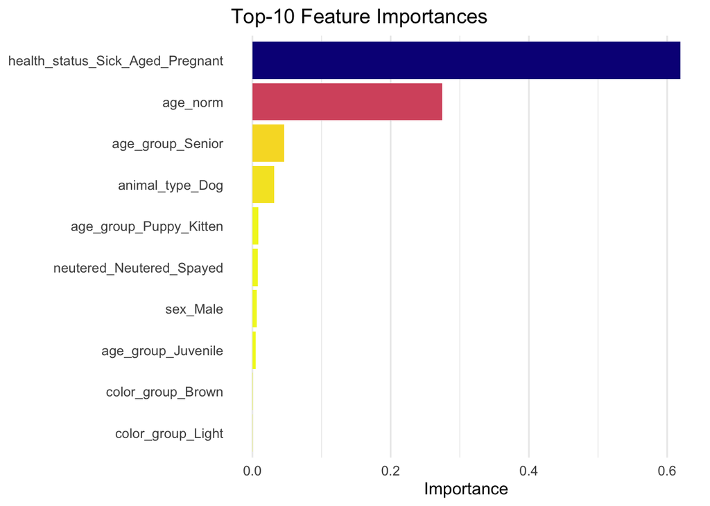

```r
trained <- fit(final_wf, train)
vip(trained$fit$fit,
    num_features = 10,
    geom         = "col",
    mapping      = aes(fill = Importance)) +
  scale_fill_viridis_c(option = "C", direction = -1) +
  labs(
    title = "Top-10 Feature Importances",
    x = NULL, y = "Importance"
  ) +
  theme_minimal(base_size = 12) +
  theme(
    legend.position    = "none",
    panel.grid.major.y = element_blank()
  )
```

Best hyper-parameters (selected on CV)

```r
print(best_params)
```

```
## # A tibble: 1 × 8
##    mtry trees min_n tree_depth learn_rate loss_reduction sample_size .config
##   <int> <int> <int>      <int>      <dbl>          <dbl>       <dbl> <chr>
## 1     7  1555    31         15     0.0129           31.6         0.4 Preprocess…
```

Hold-out test metrics

```r
test_metrics <- collect_metrics(final_res)
print(test_metrics)
```

```
## # A tibble: 6 × 4
##   .metric  .estimator .estimate .config
##   <chr>    <chr>          <dbl> <chr>
## 1 accuracy binary         0.786 Preprocessor1_Model1
## 2 sens     binary         0.796 Preprocessor1_Model1
## 3 spec     binary         0.683 Preprocessor1_Model1
## 4 f_meas   binary         0.872 Preprocessor1_Model1
## 5 roc_auc  binary         0.822 Preprocessor1_Model1
## 6 pr_auc   binary         0.975 Preprocessor1_Model1
```

Extract accuracy

```r
acc <- test_metrics %>% filter(.metric == "accuracy") %>% pull(.estimate)
cat(sprintf("\nAccuracy: %.3f  |  Misclassification error: %.3f\n",
            acc, 1 - acc))
```

```
##
## Accuracy: 0.786  |  Misclassification error: 0.214
```

ROC-AUC

```r
preds <- collect_predictions(final_res)
preds$y_true <-ifelse(preds$outcome_type=="Adopted",1,0)

roc_obj <- roc(preds$y_true, preds$.pred_Adopted)
auc_value <- auc(roc_obj)
print(paste("AUC:", round(auc_value, 3)))
```

```
## [1] "AUC: 0.822"
```

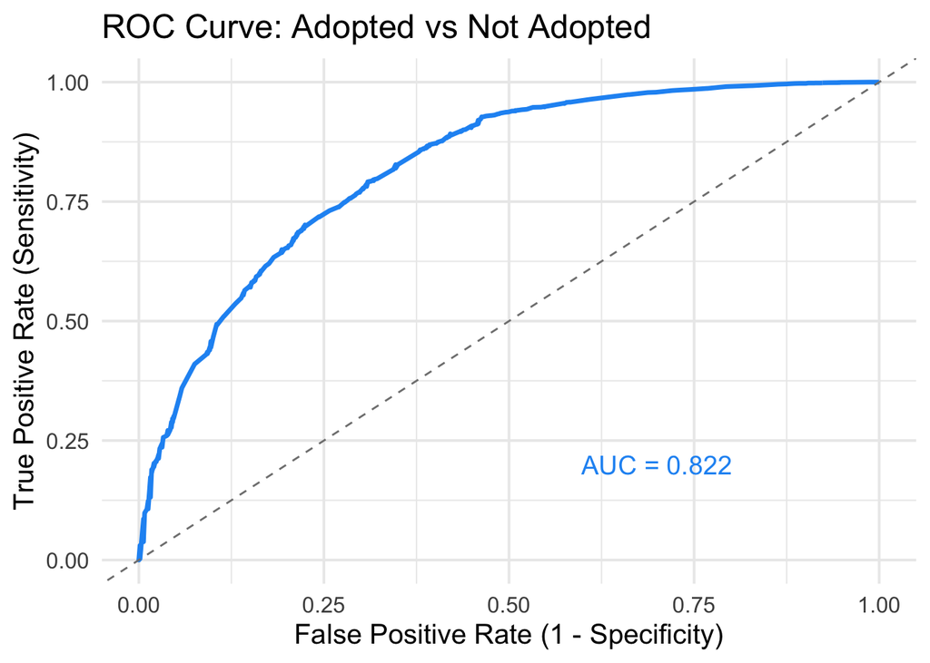

```r
roc_df <- data.frame(
  tpr = roc_obj$sensitivities,
  fpr = 1 - roc_obj$specificities
)

ggplot(roc_df, aes(x = fpr, y = tpr)) +
  geom_line(color = "#2196f3", size = 1.2) +
  geom_abline(linetype = "dashed", color = "grey50") +
  annotate("text", x = 0.7, y = 0.2,
           label = paste("AUC =", round(auc_value, 3)), size = 5, color = "#2196f3") +
  labs(title = "ROC Curve: Adopted vs Not Adopted",
       x = "False Positive Rate (1 - Specificity)",
       y = "True Positive Rate (Sensitivity)") +
  theme_minimal(base_size = 15)
```

XGBoost model summary

```r
trained_fit <- pull_workflow_fit(trained)
print(trained_fit$fit)
```

```
## ##### xgb.Booster
## raw: 267 Kb
## call:
##   xgboost::xgb.train(params = list(eta = 0.0129154966501488, max_depth = 15L,
##     gamma = 31.6227766016838, colsample_bytree = 1, colsample_bynode = 0.636363636363636,
##     min_child_weight = 31L, subsample = 0.4), data = x$data,
##     nrounds = 1555L, watchlist = x$watchlist, verbose = 0, early_stopping_rounds = 20,
##     objective = "binary:logistic", eval_metric = "auc", nthread = 7)
## params (as set within xgb.train):
##   eta = "0.0129154966501488", max_depth = "15", gamma = "31.6227766016838", colsample_bytree = "1", colsample_bynode = "0.636363636363636", min_child_weight = "31", subsample = "0.4", objective = "binary:logistic", eval_metric = "auc", nthread = "7", validate_parameters = "TRUE"
## xgb.attributes:
##   best_iteration, best_msg, best_ntreelimit, best_score, niter
## callbacks:
##   cb.evaluation.log()
##   cb.early.stop(stopping_rounds = early_stopping_rounds, maximize = maximize,
##     verbose = verbose)
## # of features: 11
## niter: 50
## best_iteration : 30
## best_ntreelimit : 30
## best_score : 0.8341411
## best_msg : [30]  training-auc:0.834141
## nfeatures : 11
## evaluation_log:
##   iter training_auc
##  <num>        <num>
##      1    0.8234372
##      2    0.8302446
##    ---          ---
##     49    0.8339892
##     50    0.8339850
```

Additional Graphs

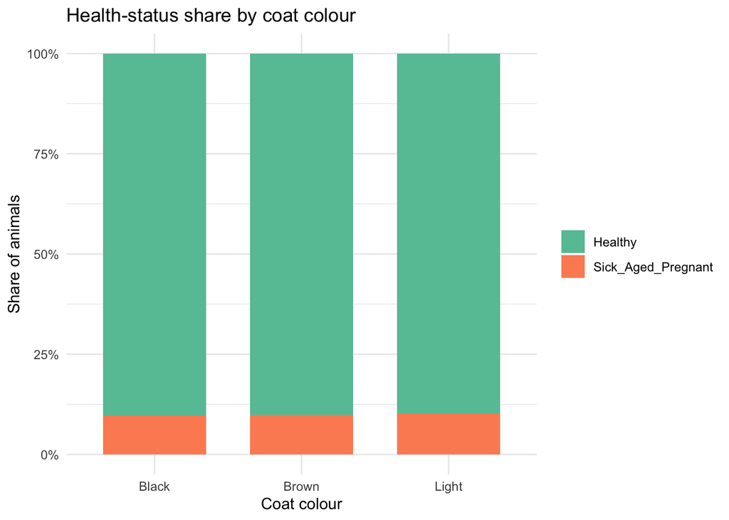

```r
df %>%
  count(color_group, health_status, name = "n") %>%
  group_by(color_group) %>%
  mutate(prop = n / sum(n)) %>%
  ungroup() %>%
  ggplot(aes(x = color_group, y = prop,
             fill = health_status)) +
  geom_col(width = .7) +
  scale_y_continuous(labels = percent_format(accuracy = 1)) +
  scale_fill_brewer(palette = "Set2") +
  labs(title = "Health-status share by coat colour",
       x = "Coat colour", y = "Share of animals") +
  theme_minimal() +
  theme(legend.title = element_blank())
```

## Observation :

Black, brown, and light-coated animals show virtually identical healthy-versus-sick shares, so health status is independent of coat colour.

[figure not shown]

```r
df %>%
  count(color_group, health_status, name = "n") %>%
  group_by(color_group) %>%
  mutate(prop = n / sum(n)) %>%
  ungroup() %>%
  ggplot(aes(x = color_group, y = prop,
             fill = health_status)) +
  geom_col(width = .7) +
  scale_y_continuous(labels = percent_format(accuracy = 1)) +
  scale_fill_brewer(palette = "Set2") +
  labs(title = "Health-status share by coat colour",
       x = "Coat colour", y = "Share of animals") +
  theme_minimal() +
  theme(legend.title = element_blank())
```